# Part II - Borrower APR and Loan Characteristics

## by Menzi Khumalo

## Investigation Overview

> In this investigation, I wanted to look at the characteristics of loans that could be used to predict their borrower APR. The main focus was on the original loan amount, borrower's Prosper rating, and borrower's stated monthly income.

## Dataset Overview

> The dataset consisted of borrower APRs and attributes of 113,937 loans. The attributes included original loan amount, borrower's Prosper rating, loan term, borrower's stated monthly income, as well as many other features such as borrower's employment status, debt to income ratio, current loan status e.t.c

## Distribution of Borrower APR in Dataset

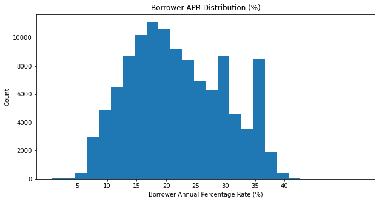

## Borrower APR vs Prosper Rating

> The borrower APR decreases with the increasingly better rating. Borrowers with the best Prosper ratings have the lowest APR. It means that the Prosper rating has a strong effect on borrower APR.

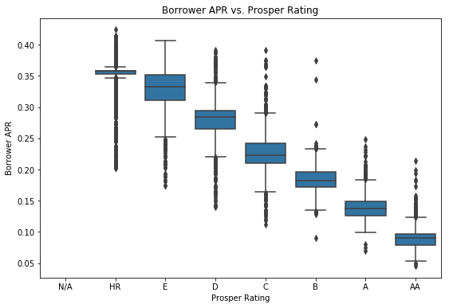

## Loan Amount effect on Borrower APR and Income rrange

> The loan amount increases with income range while the borrower APR decreases with Loan Original amount. That is people who earn more income take high loan amounts while the APR decreases as loan amount increases.

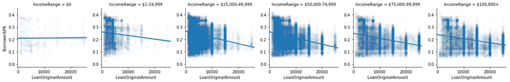